# Análisis de clases latentes con tidySEM y openMX

2023-11-29

Vamos a utilizar los siguientes paquetes. La instalación de tidySEM es un poco tardada.

```r
library(pacman)
p_load(tidySEM, ggplot2, data.table, dplyr)
```

Para nuestro ejemplo utilizaremos los datos de la ENIGH 2008 (una muestra solamente).

Además calcularemos el score tot_iamen que usa CONEVAL para construir los cuatro grupos de inseguridad alimentaria (iagrupos).

```r
D<-fread("DatosEMSA2008.csv")
D$tot_iamen<-rowSums(D[,2:13])
D$iagrupos<-ifelse(D$tot_iamen==0,0,
                   ifelse(D$tot_iamen>=1 & D$tot_iamen<=3, 1,
                     ifelse(D$tot_iamen>=4 & D$tot_iamen<=7, 2,3)))
```

Solamente para mostrar algunas de las funciones de tidySEM, usaremos la función descriptives

```r
set.seed(123)

desc <- tidySEM::descriptives(D)
desc <- desc[, c("name", "type", "n", "missing", "unique", "mode",
"mode_value", "v")]
desc
```

```
##         name    type    n missing unique   mode mode_value  v
## 1         V1 integer 2000       0   2000 1000.5         NA NA
## 2     ia_1ad integer 2000       0      2    0.0         NA NA
## 3     ia_2ad integer 2000       0      2    0.0         NA NA
## 4     ia_3ad integer 2000       0      2    0.0         NA NA
## 5     ia_4ad integer 2000       0      2    0.0         NA NA
## 6     ia_5ad integer 2000       0      2    0.0         NA NA
## 7     ia_6ad integer 2000       0      2    0.0         NA NA
## 8    ia_7men integer 2000       0      2    0.0         NA NA
## 9    ia_8men integer 2000       0      2    0.0         NA NA
## 10   ia_9men integer 2000       0      2    0.0         NA NA
## 11  ia_10men integer 2000       0      2    0.0         NA NA
## 12  ia_11men integer 2000       0      2    0.0         NA NA
## 13  ia_12men integer 2000       0      2    0.0         NA NA
## 14     plb_m integer 2000       0      2    0.0         NA NA
## 15 tot_integ integer 2000       0     16    4.0         NA NA
## 16 tot_iamen numeric 2000       0     13    0.0         NA NA
## 17  iagrupos numeric 2000       0      4    0.0         NA NA
```

Un requisito para estimar modelos de clases latentes con `tidySEM` para variables ordinales es convertir los indicadores de interés a factores ordenados. Esto se hace con la función `factor`. Para hacerlo en un paso, usamos `mutate_at` del paquete `dplyr`.

```r
tofactor<-function(x) factor(x, ordered = T)
D %>% mutate_at(c("ia_1ad", "ia_2ad", "ia_3ad", "ia_4ad", "ia_5ad", "ia_6ad", "ia_7men", "ia_8men", "ia_9men", "ia_10men", "ia_11men", "ia_12men"), tofactor) -> D
```

Una ventaja de usar tidySEM es que podemos iterar los modelos más fácilmente. Esto se hace con la función `mx_lca`. Pediremos que estime modelos de una hasta cuatro clases.

Nota: Estos cuatro modelos se tardarán varios minutos (10-20 min aprox). Paciencia.

Guardamos los resultados en el objeto “res” para no tener que perder tiempo re-estimando.

```r
#res <- mx_lca(data = D[,2:13], classes = 1:4)
#save(res, file="res")
load("res")
```

La evaluación de los modelos de clases latentes requiere la inspección conjunta de varios estadísticos.

- LL: Valor del logaritmo de la función de verosimilitud
- n: tamaño de muestra
- Parameters: número de parámetros del modelo
- BIC: Bayesian Information Criterion
- Entropy: Entropia (>.9)
- prob_munL: probabilidad mínima de éxito (>.9)
- n_min: número de casos de la clase más pequeña (>5%)
- np_ratio: Observaciones por parámetros
- np_local: Tamaño de clase por parámetro

```r
fit <- table_fit(res)
fit[, c("Name", "LL", "n", "Parameters", "BIC", "Entropy", "prob_min",
"n_min", "np_ratio", "np_local")]
```

```
##   Name         LL    n Parameters      BIC   Entropy  prob_min  n_min  np_ratio
## 1    1 -10634.870 2000         12 21360.95 1.0000000 1.0000000 1.0000 166.66667
## 2    2  -6798.900 2000         25 13787.82 0.9557201 0.9609262 0.2355  80.00000
## 3    3  -6329.718 2000         38 12948.27 0.9498293 0.9383590 0.0710  52.63158
## 4    4  -6033.974 2000         51 12455.59 0.8958181 0.8175077 0.0655  39.21569
##    np_local
## 1 166.66667
## 2  39.25000
## 3  11.83333
## 4  10.91667
```

Podemos graficar el valor del BIC

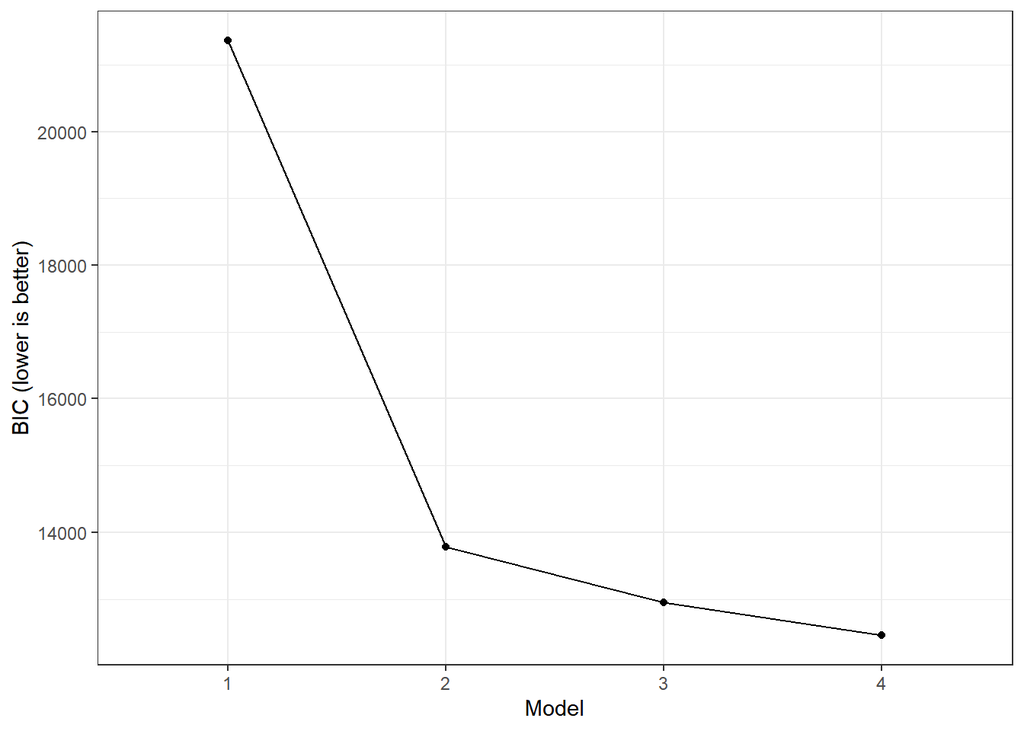

```r
plot(fit)
```

De acuerdo a los criterios de arriba, el modelo de tres clases resultó ser el mejor.

```r
res_final <- res[[3]]
tab <- table_prob(res_final)
reshape(tab, direction = "wide", v.names = "Probability", timevar = "group",
idvar = c("Variable", "Category"))
```

```
##    Variable Category Probability.class1 Probability.class2 Probability.class3
## 1    ia_1ad        1         0.17825160       4.665579e-02       8.833910e-01
## 2    ia_1ad        2         0.82174840       9.533442e-01       1.166090e-01
## 3    ia_2ad        1         0.61433559       1.435982e-01       9.956124e-01
## 4    ia_2ad        2         0.38566441       8.564018e-01       4.387625e-03
## 5    ia_3ad        1         0.34074397       4.883041e-02       9.732129e-01
## 6    ia_3ad        2         0.65925603       9.511696e-01       2.678707e-02
## 7    ia_4ad        1         0.64689551       1.798480e-01       1.000000e+00
## 8    ia_4ad        2         0.35310449       8.201520e-01       0.000000e+00
## 9    ia_5ad        1         0.59665104       8.999054e-02       1.000000e+00
## 10   ia_5ad        2         0.40334896       9.100095e-01       1.110223e-16
## 11   ia_6ad        1         0.71142762       2.175384e-01       1.000000e+00
## 12   ia_6ad        2         0.28857238       7.824616e-01       0.000000e+00
## 13  ia_7men        1         0.37727227       0.000000e+00       9.544566e-01
## 14  ia_7men        2         0.62272773       1.000000e+00       4.554343e-02
## 15  ia_8men        1         0.55164294       9.044183e-03       1.000000e+00
## 16  ia_8men        2         0.44835706       9.909558e-01       0.000000e+00
## 17  ia_9men        1         0.59773751       1.405975e-02       9.979558e-01
## 18  ia_9men        2         0.40226249       9.859403e-01       2.044193e-03
## 19 ia_10men        1         0.91687350       1.191644e-32       1.000000e+00
## 20 ia_10men        2         0.08312650       1.000000e+00       0.000000e+00
## 21 ia_11men        1         0.89409765       1.462365e-01       1.000000e+00
## 22 ia_11men        2         0.10590235       8.537635e-01       0.000000e+00
## 23 ia_12men        1         0.94784684       2.583380e-01       1.000000e+00
## 24 ia_12men        2         0.05215316       7.416620e-01       0.000000e+00
```

Para graficar los resultados de la solución de tres clases utilizamos `plot_prob`. La clase tres seria la de los no carentes y la 1 y la 2 las de los carentes alimentarios.

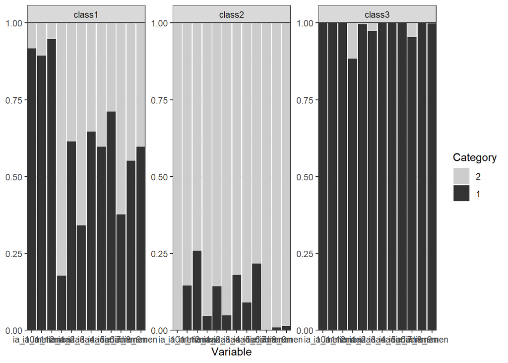

```r
plot_prob(res_final, bw = TRUE)
```

# Comparamos la clasificación manual con la basada en el LCA

Para ello predecimos para cada persona en la muestra su membresía de clase y extraemos la columna de interés.

```r
Pred<-class_prob(res_final)
D$Pred<-Pred$individual[,4]
```

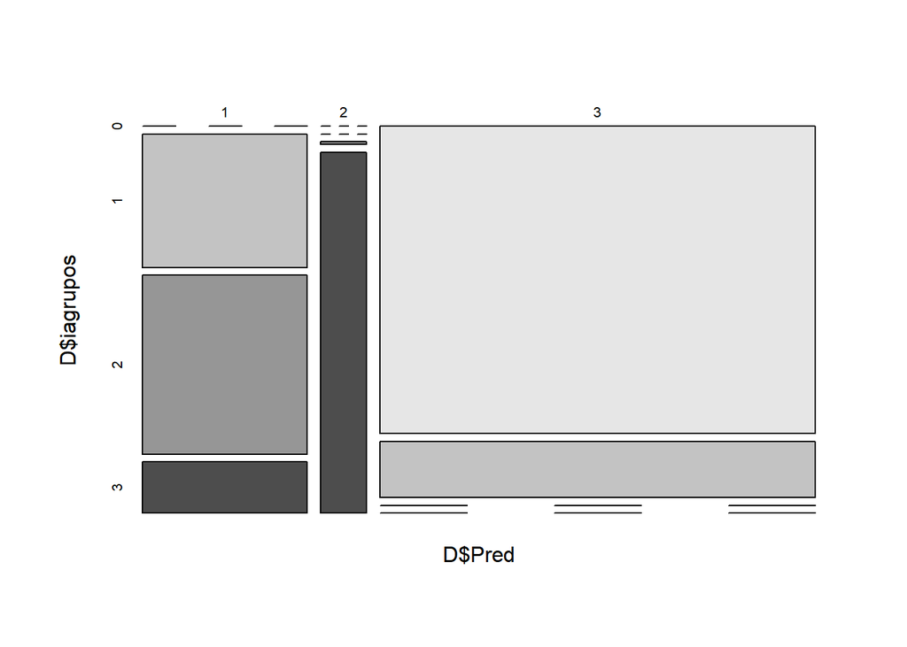

```
##    Cell Contents
## |-------------------------|
## |                   Count |
## |           Total Percent |
## |-------------------------|
##
## ==========================================
##               D$Pred
## D$iagrupos        1      2       3   Total
## ------------------------------------------
## 0                0      0    1139    1139
##                0.0%   0.0%   57.0%
## ------------------------------------------
## 1              187      0     209     396
##                9.3%   0.0%   10.4%
## ------------------------------------------
## 2              251      1       0     252
##               12.6%   0.0%    0.0%
## ------------------------------------------
## 3               72    141       0     213
##                3.6%   7.0%    0.0%
## ------------------------------------------
## Total          510    142    1348    2000
## ==========================================
```

```r
library(descr)
crosstab(D$iagrupos,D$Pred, prop.t = T)
```

# Análisis con variables auxiliares

La función BCH aplica el análisis conocido como de tres pasos, el cual compara las clases usando un modelo multigrupo, que controla por error de clasificación. Por ejemplo, se puede analizar si cierto factor como la pertenencia al grupo pobre o no pobre por ingresos varia entre las tres clases. Como esperábamos, sí hay relación.

```r
aux_dep <- BCH(res_final, data = D$plb_m)
```

```
## Running aux with 6 parameters
```

```r
lr_test(aux_dep)
```

```
## Running aux with 2 parameters
```

```
## Running aux with 4 parameters
## Running aux with 4 parameters
## Running aux with 4 parameters
```

```
## BCH test for equality of means across classes
##
## Overall likelihood ratio test:
##  LL_baseline LL_restricted   LL_dif df            p
##      1888.62      2103.774 215.1536  4 2.068883e-45
##
## Pairwise comparisons using likelihood ratio tests:
##  Model1 Model2 LL_baseline LL_restricted    LL_dif df            p
##  class1 class2     1888.62      1900.679  12.05883  2 2.406900e-03
##  class1 class3     1888.62      2026.887 138.26685  2 9.456593e-31
##  class2 class3     1888.62      2022.639 134.01905  2 7.909202e-30
```

Para ver los valores de los coeficientes utilizamos:

S: Slope M: Mean/threshold

Vemos que la clase 3 tiene menos probabilidad de contar con gente pobre por ingresos.

```r
aux_dep$estimate
```

[output not shown]

¿Cambia la relación entre plb_m según número de integrantes del hogar?

De acuerdo a los test de wald, no hay variabilidad entre clases.

```r
df_aux <- D[, c("plb_m",  "tot_integ")]
aux_model <- BCH(res_final, model = "plb_m ~ tot_integ",
data = df_aux)
```

```
## Running aux with 15 parameters
```

```r
coef(aux_model)
```

```
## class1.A[1,2] class1.S[1,1] class1.S[2,2] class1.M[1,1] class1.M[1,2]
##    0.03236464    0.21401044    3.00771062    0.16080663    4.88118512
## class2.A[1,2] class2.S[1,1] class2.S[2,2] class2.M[1,1] class2.M[1,2]
##    0.04677856    0.23805369    4.98023998    0.22052432    5.28228357
## class3.A[1,2] class3.S[1,1] class3.S[2,2] class3.M[1,1] class3.M[1,2]
##    0.03445457    0.12039569    2.75574997   -0.01434069    4.61208076
```

```r
wald_test(aux_model,
"class1.A[1,2]=class2.A[1,2]&class1.A[1,2]=class3.A[1,2]")
```

```
## Wald chi-square tests for linear hypotheses:
##                                               Hypothesis df     chisq         p
##  class1.A[1,2]=class2.A[1,2]&class1.A[1,2]=class3.A[1,2]  2 0.4738226 0.7890613
```